# Simulating a Two-Player Dice Game

Team 49 Project Report  
Simulation (ISYE 6644) – Fall 2021  
Steven Dutschke (sdutschke@gatech.edu)  
Nadav Rindler (nrindler3@gatech.edu)  
11/23/2021

### Abstract

We simulate a two-player dice game in Python to obtain the expected number and distribution of cycles the game will last for (Project prompt #14). The game is a simple two player dice game with the goal being to outlast your opponent and not lose all of your coins. The rules of game as:

- Two players start with 4 coins each, with two coins in the pot.
- The players take turns tossing a six-sided die, and depending on the value of the die, each player either adds or subtracts from the coins in the pot, or else takes no action.
- The game ends when one player is unable to perform the task, i.e., runs out of coins and can no longer add coins to the pot.

We use simulation and first step analysis to describe key characteristics of the game, yielding an expected value and distribution of the number of cycles in each game.

- We observe a mean of 14.8 and a median of 13 cycles across 1 million simulated replications of the game.
- We demonstrate that as few as 10,000 replications yields an expected value within 0.5% of the expected value obtained from the full 1 million replications.
- We use batch means to estimate a 95% confidence interval of 14.8 $\pm$ 0.016 cycles.
- We use Python to test and select a line from a gamma distribution that best fits the observed distribution from the simulation.
- We validate the results of our simulation using a Markov Chain first-step analysis, which yields an expected value of 14.6 cycles.
- Our simulation and first step analysis can be extended for this game given any possible allocation of the starting 10 coins.

### Background

Simulation is the imitation of the operation of a real-world process or system over time. Simulation helps us describe and analyze system behavior, and to answer 'what if' questions. In this study, we use a simple two-player dice game to demonstrate powerful techniques that can be applied to model much more complicated systems.

Simulation sheds light on how soon the game will typically take to terminate, outputting the expected value (mean) number of cycles in the game as well as a distribution of values that we can later fit a model to. In parallel to simulation, we obtained the expected value for the number of cycles from the game using first-step analysis.

First step analysis is a method for evaluating a Markov Chain, which requires definition:

> A Markov chain is a mathematical system that experiences transitions from one state to another according to certain probabilistic rules. The defining characteristic of a Markov chain is that no matter how the process arrived at its present state, the possible future states are fixed. In other words, the probability of transitioning to any particular state is dependent solely on the current state and time elapsed.$^1$

Our dice game is a Markov Chain because each turn (each die roll) is independent of one another. The number of coins that Player A/B/pot have at the end of a turn *depends solely on the number of coins they have at the start of the turn.* The past history of turns is irrelevant for determining the coint count after the turn. Instead, the value of the random die toss determines the coin counts after the turn, and the probability of each die value is known. Thus we can assign probability $P_{ij}$ that any starting state $i$ leads to any potential next state $j$, and these probabilities can be stored in a transition probability matrix $M$.

What happens when one player loses? The game ends. This is called an absorbing state, and is encoded as the transition probability $P_{ij} = 1$. There are many absorption states and many transition states, depending on the parameters of the Markov Chain. As we show below, this two-player die game contains 91 potential states of which 25 are absorbing states.

The first step analysis helps to answer the question of how long it takes on average to reach one of the absorbing states.$^2$ This is analogous to obtaining the mean number of cycles from a simulation. We can compare the result of the first step analysis to the simulation to see how close the two methods are.

### Simulation

```python
# load packages
import random
import matplotlib.pyplot as plt
import math
import numpy as np
import seaborn as sns
import scipy
import scipy.stats
import pandas as pd
import statistics
import warnings
import statsmodels.api as sm
from statsmodels.graphics.gofplots import qqplot_2samples
from sklearn.metrics import r2_score
```

We simulate one million replications of the dice game in order to obtain an expected value and distribution of the number of cycles the game takes to terminate.

We begin by generating pseudo-random numbers using Python's "random" package to output integers in range [1,6] to simulate the a roll of the die.$^3$

```python
def randgen():
    #return number from 1-6
    return random.randrange(1,7,1)
```

Next we define an $action()$ function that reflects the potential outcome of each turn, i.e., one die toss. The function takes as inputs the starting coins in the player's cup (turn_count), the number of coins in the pot (coincup_count), and the value of the die (output from the PRN generator above).

Per the rules of the game (see Appendix), If the player rolls a:

- 1, then the player does nothing.
- 2: then the player takes all coins in the pot.
- 3: then the player takes half of the coins in the pot (rounded down).
- 4,5,6: then the player puts a coin in the pot.

After each turn, the $action()$ function outputs the updated number of coins in the player's cup (turn_count) and the number of coins in the pot (coincup_count).

```python
#define the scoring action, returns the coin count and cup count regardless if it is negative
def action(turn_count,coincup_count,dice):
        if dice==1:
            return(turn_count,coincup_count)
        elif dice==2:
            turn_count=turn_count+coincup_count
            coincup_count=0
            return(turn_count,coincup_count)
        elif dice==3:
            turn_count=turn_count+math.floor(coincup_count/2)
            coincup_count=math.floor(coincup_count/2)+1
            return(turn_count,coincup_count)
        else:
            turn_count=turn_count-1
            coincup_count=coincup_count+1
            return(turn_count,coincup_count)
```

Finally, we create our main $simulation()$ program. This function takes as inputs the number of coins allocated to Player A (A), Player B (B), and the pot (C) at the start of the game. At each turn, the dice roll is a randomly generated integer from the $randgen()$ function above. Each player's turn occurs by calling the $action()$ function previously defined. After each turn, the number of coins in the player's hand and the pot are updated. If after one full cycle (i.e., both Player A and Player B take their turn) one player has no coins *and is required to pay coins into the pot because they rolled a 4/5/6*, then the game ends. The total number of cycles (including the final cycle) is appended to the cycle_counter list. The cycle_counter list will have one item for each replication of the simulation.

```python
# Set up counter
cycle_counter = []

def simulation(A,B,C):

    #A is the number of coins that A starts with. B is the number of coins that B starts with
    #coincup= number of coins in pot
    A0=A
    B0=B
    coincup=C

    #cycle count start
    cycle=1
    #initialize the floor loop
    test_score=0
    while test_score==0:
        #Roll dice
        dice=randgen()
        #A turn
        A0,coincup=action(A0,coincup,dice)
        #B turn
        B0,coincup=action(B0,coincup,dice)
        #Check if A or B runs out of coins and loses the tame
        if ((A0< 0) or (B0<0)):
            cycle_counter.append(cycle)
            test_score=1
        cycle=cycle+1
```

We execute our $simulation()$ function inputting the number of starting coins for Player A, Player B, and the pot (4, 4, and 2, respectively). This function is extendable to allow the analyst to input any (positive integer) starting values for the game. Future analysis could evaluate how sensitive the expected value and distribution of cycles is to the starting coin counts.

Note we also set a random seed with an arbitrary integer value (237) for replicability. Since the PRN generator is deterministic, the same random seed value will produce an identical sequence of PRNs every time it is run.

```python
#Set random seed
rng=random.seed(237)

# Set number of replications
# Run simulation
for j in range(1000000):
    simulation(4,4,2)
```

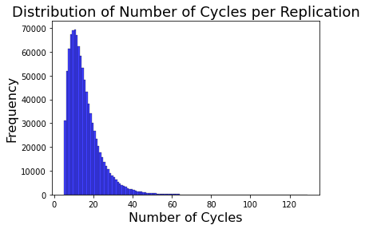

```python
sns.histplot(cycle_counter, kde=False, color='blue', bins=(np.max(cycle_counter) -  np.min(cycle_counter)))
plt.title('Distribution of Number of Cycles per Replication', fontsize=18);
plt.xlabel('Number of Cycles', fontsize=16);
plt.ylabel('Frequency', fontsize=16);
```

```python
print('Given','{:,}'.format(len(cycle_counter)),'replications, we observe a mean of',round(np.mean(cycle_counter),3),
      'cycles and a median of',np.median(cycle_counter),'cycles.')
print('The min and max number of cycles observed are',
     np.min(cycle_counter),'and',np.max(cycle_counter),', respectively.')
```

```
Given 1,000,000 replications, we observe a mean of 14.803 cycles and a median of 13.0 cycles.
The min and max number of cycles observed are 5 and 129 , respectively.
```

#### Number of replications

We chose to run 1 million replications of the simulation. What expected value would we have obtained had we decided to run fewer replications? Note, since the simulation replications are iid, there is no serial correlation between replications and thus no initialization bias to be concerned about.

```python
n = [50,100,200,500,1000,2000,3000,4000,5000,10000]
r_means = [np.mean(cycle_counter[0:n[0]]),
                       np.mean(cycle_counter[0:n[1]]),
                        np.mean(cycle_counter[0:n[2]]),
                        np.mean(cycle_counter[0:n[3]]),
                        np.mean(cycle_counter[0:n[4]]),
                        np.mean(cycle_counter[0:n[5]]),
                        np.mean(cycle_counter[0:n[6]]),
                        np.mean(cycle_counter[0:n[7]]),
                        np.mean(cycle_counter[0:n[8]]),
                        np.mean(cycle_counter[0:n[9]])
                       ]
df = pd.DataFrame({'num_reps': n, 'r_mean': r_means})
print('The expected value with 10,000 replications is within',
      "{:.1%}".format((df['r_mean'].loc[9]/np.mean(cycle_counter)-1)),
      'of the expected value with 1,000,000 replications.')
```

```
The expected value with 10,000 replications is within 0.5% of the expected value with 1,000,000 replications.
```

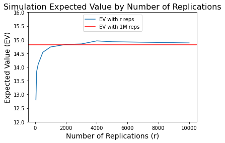

```python
graph = sns.lineplot(data=df, x="num_reps", y="r_mean", label="EV with r reps")
graph.axhline(np.mean(cycle_counter), color='r', label='EV with 1M reps')
plt.ylim(12, 16)
plt.title('Simulation Expected Value by Number of Replications', fontsize=16);
plt.xlabel('Number of Replications (r)', fontsize=14);
plt.ylabel('Expected Value (EV)', fontsize=14);
plt.legend(loc='upper center');
plt.show()
```

Taking the expected value after as few as 2,000 replications begins to closely approximate the expected value with 1 million replications.

#### Confidence Interval

Now that we have the expected value for the number of cycles in a game, we can produce a 95% confidence interval using the batch means method. Our analysis above suggests that a batch size (m) of 10,000 should get us pretty close to the expected value we obtained from the full simulation with 1,000,000 replications. That yields 100 batches (b=100).

The confidence interval is given by $\mu \pm t_{\alpha /2, b-1}\sqrt{\hat{V}_B/n}$

```python
# Get batch means
def batchmeans(l, n):
    n = max(1, n)
    a = (l[i:i+n] for i in range(0, len(l), n))
    b = list(a)
    c = list(map(np.mean,b))
    return (c)

# Set m=10,000 and b=100
m = 10000
b = len(cycle_counter)/m
t = batchmeans(cycle_counter,m)
```

```python
Mu = np.mean(cycle_counter) # sample mean from full simulation
CI_half = scipy.stats.t.ppf(1-0.025, m-1)*np.sqrt(statistics.variance(cycle_counter)/len(cycle_counter))
CI_upper = Mu + CI_half
CI_lower = Mu - CI_half
print('95% confidence interval for batch means (m=10000, b=100) == [',round(CI_lower,3),',',round(CI_upper,3),
      '] with expected value Mu ==',round(Mu,3))
```

```
95% confidence interval for batch means (m=10000, b=100) == [ 14.787 , 14.819 ] with expected value Mu == 14.803
```

Thus we are able to achieve a very tight confidence interval around our expected value of 14.80 cycles per game.

#### How quickly can you lose the game?

As an interesting aside, given the rules of the game, we know that the minimum possible number of cycles is 5: each player starts with 4 coins at at worst loses 1 coin per cycle (with a roll of 4, 5, or 6). Thus it takes a minimum of 5 turns for the player to lose by having no coins in their hand and owing one to the pot. This requires 5 consecutive die rolls of 4/5/6. The probability of losing in 5 turns is $0.5^5 = 0.03125$, since a roll of 4/5/6 occurs with a probability of 50% each time. How does this compare with the simulation output?

```python
print('The percentage of simulation replications terminating in 5 cycles =',
      "{:.3%}".format(cycle_counter.count(5)/len(cycle_counter)))
```

```
The percentage of simulation replications terminating in 5 cycles = 3.119%
```

#### Fitting a Distribution

Now that we have generated an empirical distribution of the number of cycles before the game ends, we can try to fit a curve to the distribution. Below we test various distributions (gamma, beta, nomral, and lognormal).

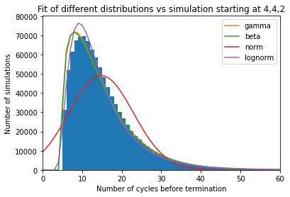

```python
warnings.filterwarnings("ignore", category=RuntimeWarning)

size = len(cycle_counter)
x = np.arange(size)
y = cycle_counter #random.sample(cycle_counter, 100000)
h = plt.hist(y, bins=range(80))

dist_names = ['gamma', 'beta', 'norm','lognorm']

for dist_name in dist_names:
    dist = getattr(scipy.stats, dist_name)
    params = dist.fit(y)
    arg = params[:-2]
    loc = params[-2]
    scale = params[-1]
    if arg:
        pdf_fitted = dist.pdf(x, *arg, loc=loc, scale=scale) * size
    else:
        pdf_fitted = dist.pdf(x, loc=loc, scale=scale) * size
    plt.plot(pdf_fitted, label=dist_name)
    plt.xlim(0,60)
plt.legend(loc='upper right')
plt.xlabel('Number of cycles before termination')
plt.ylabel('Number of simulations')
plt.title('Fit of different distributions vs simulation starting at 4,4,2')
plt.show()
```

- The normal distribution is clearly a poor fit to the data.
- The beta and gamma fitted distributions are nearly identical, and appear to fit the empirical distribution well.
- The lognormal distribution also appears to be a good fit, better reflecting the shape of the distribution but with a peak that is clearly higher than the empirical distribution.

Let's select the gamma and lognormal distributions to further evaluate which option better fits our simulation output.

```python
# Fit gamma distribution
gamma_dist = getattr(scipy.stats, 'gamma').fit(y)
gamma_y = scipy.stats.gamma.rvs(gamma_dist[0], loc=gamma_dist[1], scale=gamma_dist[2], size=size)
```

```python
# Fit lognorm dist
lognorm_dist = getattr(scipy.stats, 'lognorm').fit(y)
lognorm_y = scipy.stats.lognorm.rvs(lognorm_dist[0], loc=lognorm_dist[1], scale=lognorm_dist[2], size=size)
```

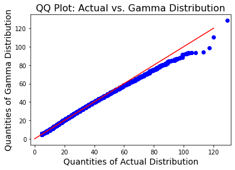

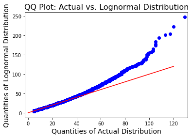

```python
# gamma
x_ = [0,120]
y_ = x_
pp_x = sm.ProbPlot(np.array(y))
pp_y = sm.ProbPlot(gamma_y)
qqplot_2samples(pp_y,pp_x)
plt.plot(x_, y_, '-r', label='y=x')
plt.title('QQ Plot: Actual vs. Gamma Distribution', fontsize=16)
plt.xlabel('Quantities of Actual Distribution', fontsize=14);
plt.ylabel('Quantities of Gamma Distribution', fontsize=14);
plt.show()

# lognorm
pp_y2 = sm.ProbPlot(lognorm_y)
qqplot_2samples(pp_y2,pp_x)
plt.plot(x_, y_, '-r', label='y=x')
plt.title('QQ Plot: Actual vs. Lognormal Distribution', fontsize=16)
plt.xlabel('Quantities of Actual Distribution', fontsize=14);
plt.ylabel('Quantities of Lognormal Distribution', fontsize=14);
plt.show()
```

```python
print("Based on the QQ plots above, we select the fitted gamma distribution as our best option, with parameters: shape =",
      round(gamma_dist[0],2),"location =",round(gamma_dist[1],2),"and scale =",round(gamma_dist[2],2),".")
```

```
Based on the QQ plots above, we select the fitted gamma distribution as our best option, with parameters: shape = 1.5 location = 4.74 and scale = 6.7 .
```

### First Step Analysis

In addition to the simulation above, we conducted a first step analysis to obtain the expected number of cycles given the starting allocation of coins.

Below we initiate three lists: for Player 1, Player 2, and the pot (Cup), which are combined into a matrix to represent all possible allocations of 10 coins between the three, which represent all 91 possible states that the game can take.

```python
Player1=[-1,0,1,2,3,4,5,6,7,8,9,10,11]
Player2=[-1,0,1,2,3,4,5,6,7,8,9,10,11]
Cup=[0,1,2,3,4,5,6,7,8,9,10,11,12]

#Combine potential states to create the matrix
Pstates=[]

for i in Player1:
    for j in Player2:
        for k in Cup:
            #check if possible state
            if i+j+k==10:
                Pstates.append([i,j,k])
#get the stationary lose values to the start of the matrix
for i in Pstates:
    if i[0]<0 or i[1]<0:
        Pstates.remove(i)
        Pstates.insert(0, i)
```

We then create four functions to represent the four distinct outcomes from one turn (one die roll). Each function takes as input the starting coins for each participant (Player A, B, and the pot), and outputs the updated coin counts after the turn takes place. Finally, we create a function called "two_functions()" which reflects the outcome of one *cycle*, i.e. two turns - one each by Player A and B.

```python
def plus1(A,B,cup):
       #value if 4-6 rolled
    A1=A-1
    B1=B
    cup1=cup+1
    return [B1,A1,cup1]

def nothing(A,B,cup):
     #value if nothing happens
    A2=A
    B2=B
    cup2=cup
    return [B2,A2,cup2]

def all_coins(A,B,cup):
     #value if you get everything
    A3=A+cup
    B3=B
    cup3=0
    return [B3,A3,cup3]

    #value if you get half rounded down
def floorchance(A,B,cup):
    A4=A+math.floor(cup/2)
    B4=B
    cup4=cup+A-A4
    return [B4,A4,cup4]

#combine two functions together for both player A & B
def two_functions(A,B,i):
    #A is the first function
    #B is the second function
    #i is the starting coin count
    mid=A(i[0],i[1],i[2])
    return (B(mid[0],mid[1],mid[2]))
```

In this game, absorption states reflect when one player loses, i.e., they end the turn with -1 coins. The following script cycles through each of the 91 potential states. It instantiates a 91x91 matrix of zero's called "Probstates." We loop through each of the 91 states:

- First, absorption states are identified and written into the Probstates matrix along the diagonal axis to create an identity matrix (row index = column index)
- Next, for transient states, each starting state has 16 potential next states based on the outcome of one cycle of the game.
  - As we saw in the previous code cell, one turn can have four different actions depending on the value of the die. 4x4 = 16 potential outcomes from one cycle (i.e., two turns).
  - Probabilities are assigned and recorded in the Probstates matrix representing the percentage likelihood that each of the 16 potential next states occur. Recall that since this game is a Markov process, the probability of the next state depends **only** on the current state and not on any prior states.

```python
#Create a Pstates zero matrix
Probstates=np.zeros((len(Pstates),len(Pstates)))
include_list=[]
include_list2=[]
absorption_state_count=0
for i in Pstates:
    if i[0]==-1:
        Probstates[Pstates.index(i),Pstates.index(i)]=1 # A goes out, absorption state
        absorption_state_count+=1
    elif i[1]==-1:
        Probstates[Pstates.index(i),Pstates.index(i)]=1 # B goes out, absorption state
        absorption_state_count+=1
    elif i[0]<1000:
        include_list2.append(i)
        include_list.append(Pstates.index(i))
        #Check to make sure we don't have any bad numbers in here
        if i[1]<1000:
            #calculate probabilities
            # a turn by a player can have 4 outcomes. So one cycle (2 turns) has 16 potential scenarios
            index_val=Pstates.index(i)

            pp1=two_functions(plus1,plus1,i)
            pp2=two_functions(plus1,all_coins,i)
            pp3=two_functions(plus1,floorchance,i)
            pp4=two_functions(plus1,plus1,i)

            n1=two_functions(nothing,plus1,i)
            n2=two_functions(nothing,all_coins,i)
            n3=two_functions(nothing,floorchance,i)
            n4=two_functions(nothing,plus1,i)

            ac1=two_functions(all_coins,plus1,i)
            ac2=two_functions(all_coins,all_coins,i)
            ac3=two_functions(all_coins,floorchance,i)
            ac4=two_functions(all_coins,plus1,i)

            fc1=two_functions(floorchance,plus1,i)
            fc2=two_functions(floorchance,all_coins,i)
            fc3=two_functions(floorchance,floorchance,i)
            fc4=two_functions(floorchance,plus1,i)

            combo=[pp1,pp2,pp3,pp4,n1,n2,n3,n4,ac1,ac2,ac3,ac4,fc1,fc2,fc3,fc4]

            # Assign the probability of moving between each of the 16 potential start-end state combinations
            Probstates[index_val,Pstates.index(two_functions(plus1,plus1,i))]+=0.25
            Probstates[index_val,Pstates.index(two_functions(plus1,all_coins,i))]+=0.0833333
            Probstates[index_val,Pstates.index(two_functions(plus1,floorchance,i))]+=0.0833333
            Probstates[index_val,Pstates.index(two_functions(plus1,plus1,i))]+=0.0833333

            Probstates[index_val,Pstates.index(two_functions(nothing,plus1,i))]+=0.0833333
            Probstates[index_val,Pstates.index(two_functions(nothing,all_coins,i))]+=0.0277777778
            Probstates[index_val,Pstates.index(two_functions(nothing,floorchance,i))]+=0.0277777778
            Probstates[index_val,Pstates.index(two_functions(nothing,plus1,i))]+=0.0277777778

            Probstates[index_val,Pstates.index(two_functions(all_coins,plus1,i))]+=0.0833333
            Probstates[index_val,Pstates.index(two_functions(all_coins,all_coins,i))]+=0.0277777778
            Probstates[index_val,Pstates.index(two_functions(all_coins,floorchance,i))]+=0.0277777778
            Probstates[index_val,Pstates.index(two_functions(all_coins,plus1,i))]+=0.0277777778

            Probstates[index_val,Pstates.index(two_functions(floorchance,plus1,i))]+=0.0833333
            Probstates[index_val,Pstates.index(two_functions(floorchance,all_coins,i))]+=0.0277777778
            Probstates[index_val,Pstates.index(two_functions(floorchance,floorchance,i))]+=0.0277777778
            Probstates[index_val,Pstates.index(two_functions(floorchance,plus1,i))]+=0.0277777778
```

```python
print('There are',np.sum(absorption_state_count),'absorption states out of',len(Probstates),'possible states.')
```

```
There are 25 absorption states out of 91 possible states.
```

We visualize the Probstates matrix below to show which combinations of the 91 possible states are most likely to occur. Absorption states ($P_{ij}=1$) are displayed in white in the top-left corner of the matrix. Combinations of states with $0 < P_{ij} < 1$ are displayed in red. The remaining combinations of states in black cannot occur based on the rules of the game ($P_{ij}=0$).

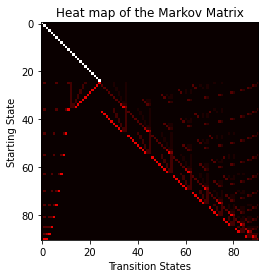

```python
plt.imshow(Probstates, cmap='hot', interpolation='nearest')
plt.title('Heat map of the Markov Matrix')
plt.xlabel('Transition States')
plt.ylabel('Starting State')
plt.show()
```

```python
start=Pstates.index([4,4,2])
i = np.sum(absorption_state_count)
startQ=start-(i-1) # remove 25 absorption states (the identity matrix above)
Q=Probstates[i:,i:]
I=np.identity(Q.shape[0])
W=np.linalg.inv(I-Q) # inverse of identity matrix I minus matrix Q
ev_fsa = W.sum(axis=1)[startQ] # sum up rows of W = total number of expected cycles to reach the absorption state
```

```python
#This the expected time to spend in a transient state if you start at [4,4,2]
print('First step analysis yields an expected value of',round(ev_fsa,3),'cycles.')
```

```
First step analysis yields an expected value of 14.569 cycles.
```

Let's compare this result for the other possible starting locations. We will do that by completing the same analysis we have shown step by step for the initial starting values with every other possible starting combination. We will compare the results using linear regression analysis to see if there is any significant difference between the two different analysis techniques.

```python
#Get the expected value using the first step analysis from the Markov Chain matrix
FSA_allstates=W.sum(axis=1)
```

```python
#Define set of possible starting locations

Pstates_valid=Pstates[25:]
#Create a storage List
P_resultstore_mean=[]
P_resultstore_median=[]

#loop over all valid states
for i in Pstates_valid:


#Set random seed
    cycle_counter = []
    rng=random.seed(237)


# Set number of replications
# Run simulation
    for j in range(10000):
        simulation(i[0],i[1],i[2])
    #np.mean(cycle_counter)
    P_resultstore_mean.append(np.mean(cycle_counter))
    P_resultstore_median.append(np.median(cycle_counter))
```

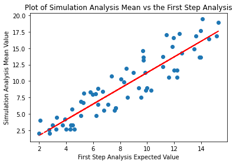

```python
plt.scatter(FSA_allstates,P_resultstore_mean)
z = np.polyfit(FSA_allstates,P_resultstore_mean, 1)
p = np.poly1d(z)
plt.plot(FSA_allstates,p(FSA_allstates),"r--")
y_hat = np.poly1d(z)(FSA_allstates)


plt.xlabel('First Step Analysis Expected Value')
plt.ylabel('Simulation Analysis Mean Value')
plt.title('Plot of Simulation Analysis Mean vs the First Step Analysis')

#for x,y,name in zip(FSA_allstates,P_resultstore_mean,Pstates_valid):
 #
  #  text='('+','.join(map(str,name))+')'
#
 #   label = "{:s}".format(text)
  #
   # plt.annotate(label, # this is the text
    #             (x,y), # these are the coordinates to position the label
     #            textcoords="offset points", # how to position the text
      #           xytext=(3,3), # distance from text to points (x,y)
       #          ha='center', # horizontal alignment can be left, right or center
        #         fontsize=8)
plt.show()
```

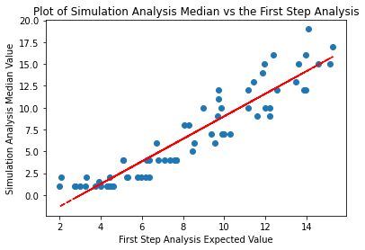

```python
plt.scatter(FSA_allstates,P_resultstore_median)

z = np.polyfit(FSA_allstates,P_resultstore_median,1)
p = np.poly1d(z)
plt.plot(FSA_allstates,p(FSA_allstates),"r--")
y_hat = np.poly1d(z)(FSA_allstates)

plt.xlabel('First Step Analysis Expected Value')
plt.ylabel('Simulation Analysis Median Value')
plt.title('Plot of Simulation Analysis Median vs the First Step Analysis')

plt.show()
```

We will now compare the mean value of the simulation to the First step analysis by using linear regression to see if there are any statistically significant difference between the simuilated results and the Markov model.

```python
import statsmodels.api as sm
FSA_allstates2 = sm.add_constant(FSA_allstates)
model = sm.OLS(P_resultstore_mean, FSA_allstates2)
results = model.fit()
print(results.summary())
```

```
                            OLS Regression Results
==============================================================================
Dep. Variable:                      y   R-squared:                       0.834
Model:                            OLS   Adj. R-squared:                  0.832
Method:                 Least Squares   F-statistic:                     321.8
Date:                Sun, 28 Nov 2021   Prob (F-statistic):           1.18e-26
Time:                        17:32:41   Log-Likelihood:                -138.51
No. Observations:                  66   AIC:                             281.0
Df Residuals:                      64   BIC:                             285.4
Df Model:                           1
Covariance Type:            nonrobust
==============================================================================
                 coef    std err          t      P>|t|      [0.025      0.975]
------------------------------------------------------------------------------
const         -0.6807      0.607     -1.121      0.267      -1.894       0.533
x1             1.1935      0.067     17.938      0.000       1.061       1.326
==============================================================================
Omnibus:                        9.872   Durbin-Watson:                   0.486
Prob(Omnibus):                  0.007   Jarque-Bera (JB):                3.157
Skew:                           0.104   Prob(JB):                        0.206
Kurtosis:                       1.949   Cond. No.                         22.7
==============================================================================

Notes:
[1] Standard Errors assume that the covariance matrix of the errors is correctly specified.
```

```python
cycle_counter=[]
rng=random.seed(237)
for j in range(100000):
    simulation(0,0,10)
```

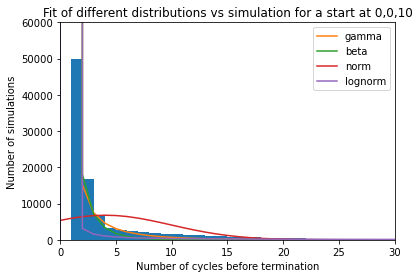

```python
warnings.filterwarnings("ignore", category=RuntimeWarning)

size = len(cycle_counter)
x = np.arange(size)
y = cycle_counter #random.sample(cycle_counter, 100000)
h = plt.hist(y, bins=range(80))

dist_names = ['gamma', 'beta', 'norm','lognorm']

for dist_name in dist_names:
    dist = getattr(scipy.stats, dist_name)
    params = dist.fit(y)
    arg = params[:-2]
    loc = params[-2]
    scale = params[-1]
    if arg:
        pdf_fitted = dist.pdf(x, *arg, loc=loc, scale=scale) * size
    else:
        pdf_fitted = dist.pdf(x, loc=loc, scale=scale) * size
    plt.plot(pdf_fitted, label=dist_name)
    plt.xlim(0,30)
    plt.ylim(0,60000)
plt.legend(loc='upper right')
plt.xlabel('Number of cycles before termination')
plt.ylabel('Number of simulations')
plt.title('Fit of different distributions vs simulation for a start at 0,0,10')
plt.show()
```

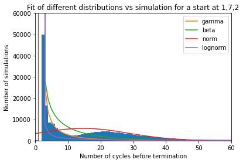

```python
cycle_counter=[]
rng=random.seed(237)
for j in range(200000):
    simulation(1,7,2)
warnings.filterwarnings("ignore", category=RuntimeWarning)

size = len(cycle_counter)
x = np.arange(size)
y = cycle_counter #random.sample(cycle_counter, 100000)
h = plt.hist(y, bins=range(80))

dist_names = ['gamma', 'beta', 'norm','lognorm']

for dist_name in dist_names:
    dist = getattr(scipy.stats, dist_name)
    params = dist.fit(y)
    arg = params[:-2]
    loc = params[-2]
    scale = params[-1]
    if arg:
        pdf_fitted = dist.pdf(x, *arg, loc=loc, scale=scale) * size
    else:
        pdf_fitted = dist.pdf(x, loc=loc, scale=scale) * size
    plt.plot(pdf_fitted, label=dist_name)
    plt.xlim(0,60)
    plt.ylim(0,60000)
plt.legend(loc='upper right')
plt.xlabel('Number of cycles before termination')
plt.ylabel('Number of simulations')
plt.title('Fit of different distributions vs simulation for a start at 1,7,2')
plt.show()
```

In the above distribution we can see a clear bimodal distribution. This makes sense as there is a clear opportunity for player A and B to have a similar number of coins at the end of the first turn or for Player A to be eliminated from the game in the second turn. To see if there is any trend in these distributions the difference between Player A and Player B's starting coins and the number of total coins in the cup at start of the game were compared against the difference between the analysis.

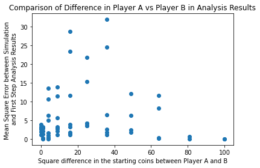

```python
#list of differences between Player A & B of starting coins
diff_AB=[]
#MSE FSA vs Simulation
diff_results=[]
#cup_coins
cup_coins=[]

#compare the differences
for x,y,name in zip(FSA_allstates,P_resultstore_mean,Pstates_valid):
    diff_AB.append((name[0]-name[1])**2)
    diff_results.append((x-y)**2)
    cup_coins.append(name[2])


#plot the differences
plt.scatter(diff_AB,diff_results)

plt.xlabel('Square difference in the starting coins between Player A and B')
plt.ylabel('Mean Square Error between Simulation \n and First Step Analysis Results')
plt.title('Comparison of Difference in Player A vs Player B in Analysis Results')
plt.show()
```

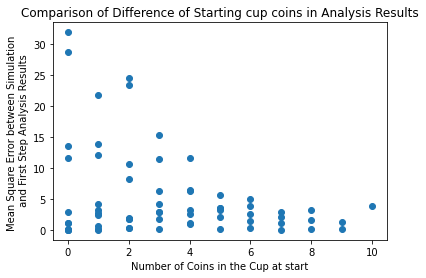

```python
plt.scatter(cup_coins,diff_results)

plt.xlabel('Number of Coins in the Cup at start')
plt.ylabel('Mean Square Error between Simulation \n and First Step Analysis Results')
plt.title('Comparison of Difference of Starting cup coins in Analysis Results')

plt.show()
```

We can see A clear link between the number of coins at the start of the game causing a large difference between the First step analysis and the simulation results. As the number of coins in the cup becomes large the two analysis approaches become more similar. The difference in the number of coins at the start of the game does not seem to have any clear linkage between the values the two analysis develop.

### Conclusion

Simulation and first step analysis are powerful tools that help us describe key characteristics of complex systems. This paper uses a simple two-player dice game, but the same methods can be applied to model real-world systems in diverse industries such as manufacturing, supply chain, reliability, and finance.

### Appendix

#### Rules of the Game

There are two players, A and B. At the beginning of the game, each starts with 4 coins, and there are 2 coins in the pot. A goes first, then B, then A,. . . . During a particular player’s turn, the player tosses a 6-sided die. If the player rolls a:</br>

- 1, then the player does nothing.
- 2: then the player takes all coins in the pot.
- 3: then the player takes half of the coins in the pot (rounded down).
- 4,5,6: then the player puts a coin in the pot.</br>

A player loses (and the game is over) if they are unable to perform the task (i.e., if they have 0 coins and need to place one in the pot). We define a cycle as A and then B completing their turns. The exception is if a player goes out; that is the final cycle (but it still counts as the last cycle).

#### References

1. Markov Chain definition: https://brilliant.org/wiki/markov-chains/
2. Description of first-step analysis: https://probabilitytopics.wordpress.com/2017/11/30/introductory-examples-on-first-step-analysis/
3. Python's Random() module's $random()$ function generates a random float uniformly in the semi-open range $[0.0, 1.0)$. PRNs are produced from a deterministic Mersenne Twister generator, which produces 53-bit precision floats and has a period of 2<sup>19937</sup>-1.$^1$ The random float values are then converted to integers using the built-in $randrange()$ function. Documentation: https://docs.python.org/3/library/random.html